# Project Week 4

Practical Machine Learning

## Overview

The objective of this Project is to predict how exercises were performed by the participants of the experiment. `classe` variable ranges from A to E, with A corresponding to the correct execution of the exercise and the other factors correspond to mistakes.

## Download and read data

Data will be downloaded from the source.

```r
trainUrl <-"https://d396qusza40orc.cloudfront.net/predmachlearn/pml-training.csv"
testUrl <- "https://d396qusza40orc.cloudfront.net/predmachlearn/pml-testing.csv"
trainFile <- "../data/pml-training.csv"
testFile  <- "../data/pml-testing.csv"
if (!file.exists("../data")) {
  dir.create("../data")
}
if (!file.exists(trainFile)) {
  download.file(trainUrl, destfile=trainFile, method="curl")
}
if (!file.exists(testFile)) {
  download.file(testUrl, destfile=testFile, method="curl")
}
```

After download, csv will be read into two data frames

```r
train <- read.csv("../data/pml-training.csv")
test <- read.csv("../data/pml-testing.csv")
```

## Data Exploration

Check the dimensions

```r
dim(train)
```

```
[1] 19622   160
```

```r
dim(test)
```

```
[1]  20 160
```

The data has 160 variables. The training dataset has 19622 observations while the test dataset contains 20 observations.

Out of the 19622 observations in the train dataset, how many have no missing values?

**Find Complete Cases**

```r
sum(complete.cases(train))
```

```
[1] 406
```

Out of the 19622 observations in the train dataset, 406 have no missing values. Need to remove NA in the Data Cleaning sub-section.

It looks like the first 6 columns are not relevant predictors

```r
names(train)
```

```
  [1] "X"                        "user_name"                "raw_timestamp_part_1"
  [4] "raw_timestamp_part_2"     "cvtd_timestamp"           "new_window"
  [7] "num_window"               "roll_belt"                "pitch_belt"
 [10] "yaw_belt"                 "total_accel_belt"         "kurtosis_roll_belt"
 [13] "kurtosis_picth_belt"      "kurtosis_yaw_belt"        "skewness_roll_belt"
 [16] "skewness_roll_belt.1"     "skewness_yaw_belt"        "max_roll_belt"
 [19] "max_picth_belt"           "max_yaw_belt"             "min_roll_belt"
 [22] "min_pitch_belt"           "min_yaw_belt"             "amplitude_roll_belt"
 [25] "amplitude_pitch_belt"     "amplitude_yaw_belt"       "var_total_accel_belt"
 [28] "avg_roll_belt"            "stddev_roll_belt"         "var_roll_belt"
 [31] "avg_pitch_belt"           "stddev_pitch_belt"        "var_pitch_belt"
 [34] "avg_yaw_belt"             "stddev_yaw_belt"          "var_yaw_belt"
 [37] "gyros_belt_x"             "gyros_belt_y"             "gyros_belt_z"
 [40] "accel_belt_x"             "accel_belt_y"             "accel_belt_z"
 [43] "magnet_belt_x"            "magnet_belt_y"            "magnet_belt_z"
```

[output cut: 39 more lines]

Check for near zero variance (?nearZeroVar) and remove 6 first columns

```r
# Remove the near zero variance predictors
nzvTraining <- nearZeroVar(train, saveMetrics=TRUE)
training <- train[,nzvTraining$nzv==FALSE]

training <- training[,7:length(colnames(training))]
```

### Data Cleaning

Remove NA

```r
training <- training[, colSums(is.na(training)) == 0]
test <- test[, colSums(is.na(test)) == 0]
dim(training)
```

```
[1] 19622    53
```

```r
dim(test)
```

```
[1] 20 60
```

The number of variables have clearly changed and now they are not equal for train and test datasets.

```r
cols <- colnames(training[, -53]) # 53th col will not be added to the testing dataset
testing <- test[cols] # only the var chosen
dim(training); dim(testing)
```

```
[1] 19622    53
```

```
[1] 20 52
```

Now the training dataset has 19622 observations and 53 variables. The testing dataset has 20 observations and 52 variables

```r
table(training$classe)
```

```
   A    B    C    D    E
5580 3797 3422 3216 3607
```

## Random Forest

### Split `training` into training and validation set

```r
set.seed(280218)
Train <- createDataPartition(training$classe, p=0.70, list=F)
trainDF <- training[Train, ]
testDF <- training[-Train, ]
```

Validation set will be used from cross validation.

The Random Forest algorithm will select the variables that are relevant. 5-fold cross validation will be used, with 500 trees.

```r
controlRf <- trainControl(method="cv", 5)
modelRf <- train(classe ~ ., data=trainDF, method="rf", trControl=controlRf, ntree=500)
modelRf
```

```
Random Forest

13737 samples
   52 predictor
    5 classes: 'A', 'B', 'C', 'D', 'E'

No pre-processing
Resampling: Cross-Validated (5 fold)
Summary of sample sizes: 10990, 10989, 10990, 10990, 10989
Resampling results across tuning parameters:

  mtry  Accuracy   Kappa
   2    0.9901726  0.9875681
  27    0.9902454  0.9876604
  52    0.9826745  0.9780813

Accuracy was used to select the optimal model using the largest value.
The final value used for the model was mtry = 27.
```

Now, predict using the validation. check the confusion matrix and get the accurary.

```r
predictRf <- predict(modelRf, testDF)
acc <- confusionMatrix(testDF$classe, predictRf)$overall['Accuracy']

estimated_error_out_of_sample <- 1 - 0.9942
acc
```

```
 Accuracy
0.9942226
```

```r
estimated_error_out_of_sample
```

```
[1] 0.0058
```

The accuracy of the model is 99.42% and the estimated error out of sample is 0.58%.

### Test set

```r
predictTest <- predict(modelRf, testing)
predictTest
```

```
 [1] B A B A A E D B A A B C B A E E A B B B
Levels: A B C D E
```

## Appendix

### 1 Pair plots

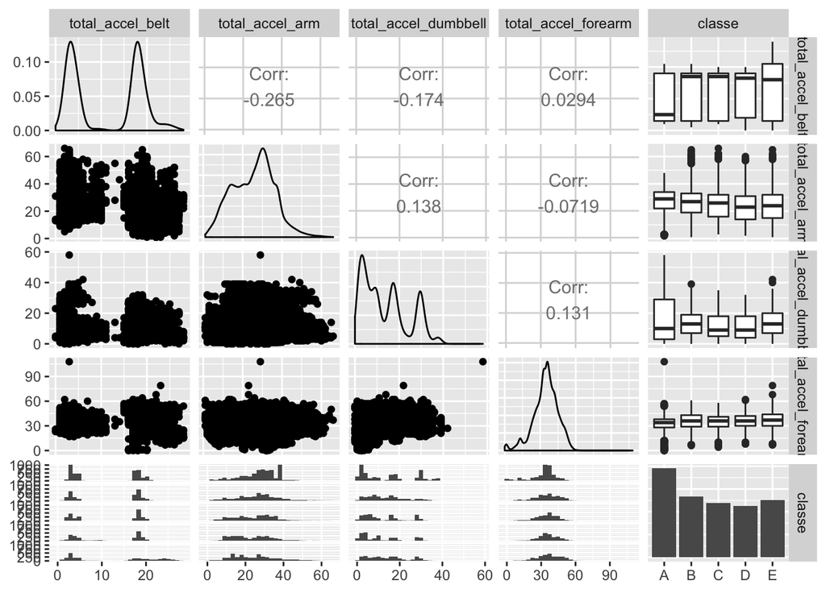

[figure not shown]

```r
ggpairs(trainDF, columns=c("total_accel_belt" , "total_accel_arm",
                           "total_accel_dumbbell", "total_accel_forearm", "classe"),
diag=list(continuous="density",   discrete="bar"), axisLabels="show")
```

### 2 Correlation Matrix

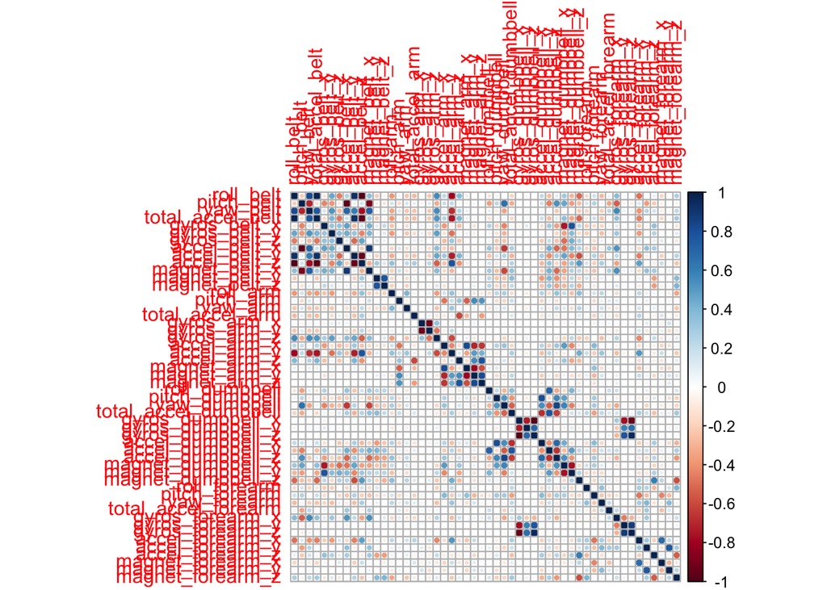

```r
corrPlot <- cor(trainDF[, -length(names(trainDF))])
corrplot(corrPlot, method="circle")
```

### 3 Decision Tree

[figure not shown]

```r
modFit <- rpart(classe ~ ., data=trainDF, method="class")
rpart.plot(modFit)
```